# Final Project

## Now let us see the distribution of age and cholesterol level attributes.

```python
#age distribution among diagonosed target
```

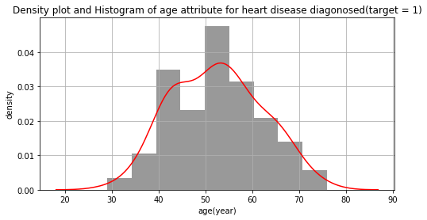

```python
sns.distplot(df_1["age"], hist = True, kde = True, color = "red", hist_kws = {"color" :"black"})
rcParams["figure.figsize"] = (11,6)
plt.title("Density plot and Histogram of age attribute for heart disease diagonosed(target = 1)")
plt.xlabel("age(year)")
plt.ylabel("density")
plt.grid(True)
plt.show()
```

**here we can clearly see that most people on their 50's are diagonosed with heart disease. Also many are diagonosed on their 40's.**

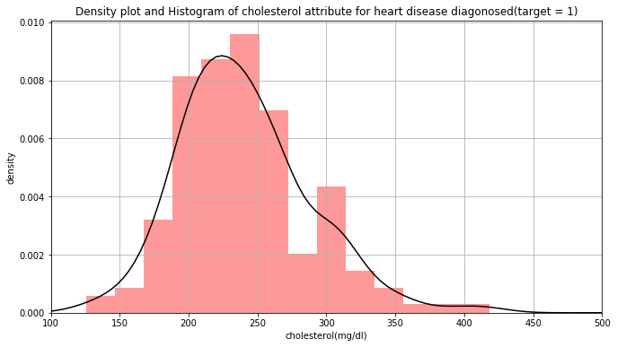

```python
sns.distplot(df_1["chol"], hist = True, kde = True, color = "black", hist_kws = {"color" :"red"})
rcParams["figure.figsize"] = (8,4)
plt.title("Density plot and Histogram of cholesterol attribute for heart disease diagonosed(target = 1)")
plt.xlim(100,500)
plt.xlabel("cholesterol(mg/dl)")
plt.ylabel("density")
plt.grid(True)
plt.show()
```

In our dataset cholestrol level of 200 to 250 mg/dl are present more with the patient diagonosed with heart disease.

#### Cholesterol level distribution with respect to age

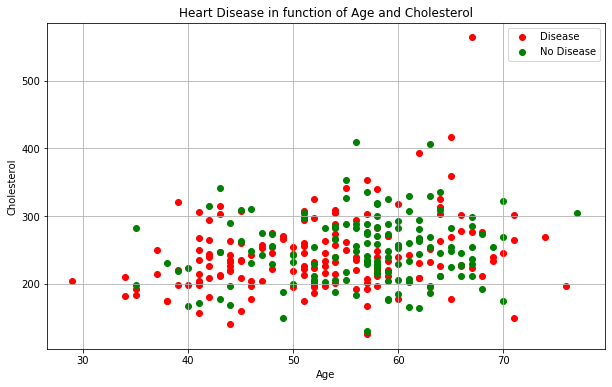

```python
# scatter plot for both target attribute
plt.figure(figsize=(10, 6))
plt.grid(True)
plt.scatter(df.age[df.target==1], df.chol[df.target==1], color ="red")
plt.scatter(df.age[df.target==0], df.chol[df.target==0], color ="green")
plt.title("Heart Disease in function of Age and Cholesterol")
plt.xlabel("Age")
plt.ylabel("Cholesterol")
plt.legend(["Disease", "No Disease"])
plt.show()
```

**here we can see that cholesterol level distribution with age. There is no any linear relationship between these two variables, any cholesterol level may have possibility of having heart disease and not have heart disease. Thus we can say cholesterol alone is not preety good indicator to predict the possibility of having heart disease**

### Features set that has positive correlation with the target variable

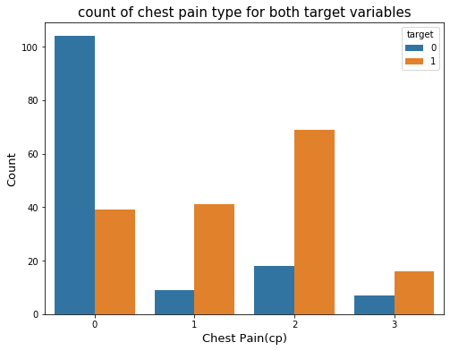

```python
# chest pain type count for target attributes.
f, ax = plt.subplots(figsize=(8, 6))
ax = sns.countplot(x="cp", hue="target", data=df)
plt.title("count of chest pain type for both target variables", fontsize = 15)
plt.xlabel("Chest Pain(cp)", fontsize = 13)
plt.ylabel("Count", fontsize = 13)
plt.show()
```

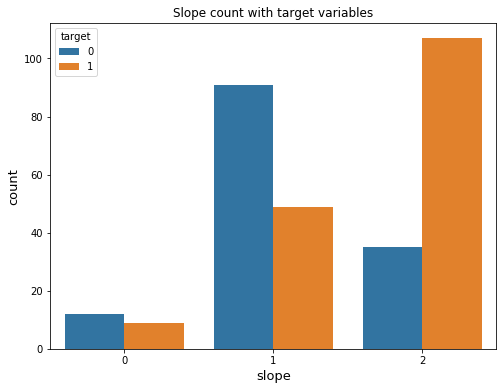

```python
# Slope vs target count.
f, ax = plt.subplots(figsize=(8, 6))
ax = sns.countplot(x="slope", hue="target", data=df)
plt.title("Slope count with target variables")
plt.xlabel("slope", fontsize = 13)
plt.ylabel("count", fontsize = 13)
plt.show()
```

Slope 0 is significantly lower, i.e. very few people have better heart rate with exercise, this is common because very minimum people have perfectly healthy heart. Slope 1 and Slope 2 are in almost same magnitude in this dataset. Slope 1 represent Flatsloping in technical term, it means the change is minimal, it represent typical healthy heart, but not perfectly healthy as slope 1 does. Slope 2 represent Downslopings in technical terminology, it means it is the sign of unhealthy heart. Larger number of people in our data set have signs of unhealthy heart. With such symptom there exists high risk of having heart attack or heart stroke.

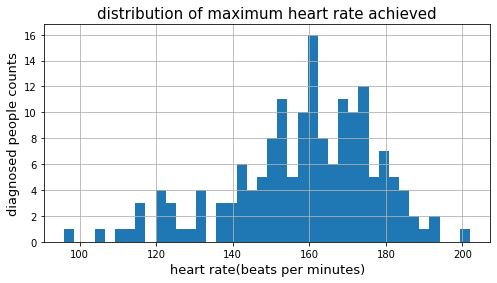

```python
# heart rate(beats per minute) count histogram plot.
df_1["thalach"].hist(bins = 40)
plt.title("distribution of maximum heart rate achieved", fontsize = 15)
plt.xlabel("heart rate(beats per minutes)", fontsize = 13)
plt.ylabel("diagnosed people counts", fontsize = 13)
plt.show()
```

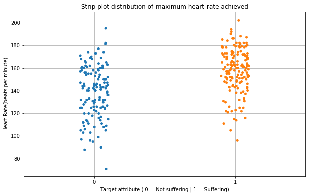

```python
#Target attribute and Heart Rate(beats per minute)

f, ax = plt.subplots(figsize=(10, 6))
sns.stripplot(x="target", y="thalach", data=df)
plt.xlabel("Target attribute ( 0 = Not suffering | 1 = Suffering)")
plt.ylabel("Heart Rate(beats per minute)")
plt.title("Strip plot distribution of maximum heart rate achieved")
plt.grid(True)
plt.show()
```

### Countplot for categorical variables sex, chest pain, fasting blood sugar(fbs), number of major vessels(ca), exercise induced angina(exang), thalium stress result(thal), slope of the peak exercise ST segment(slope) and rest electrocardiographic results(restecg).

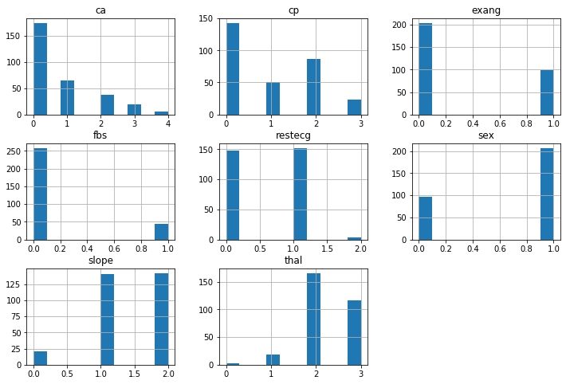

```python
df[["sex","cp","fbs","ca","exang","thal","slope","restecg"]].hist(figsize=(12,8));
```

**One of the limitation in my analysis of this heart disease dataframe from UCI is the confusion in the proper understanding of one of the attribute called "thal", which is thalium stress result. In UCI machine learning repository it is stated to have value thal: 3 = normal; 6 = fixed defect; 7 = reversable defect, but in the dataframe it has categorical value of 0,1,2 and 3. It is quiet unclear the meaning of these values and especially for the student of non-medical background it is quiet hard to visualize unclear attributes.**

**Number of male with heart disease are larger than the number of female.**

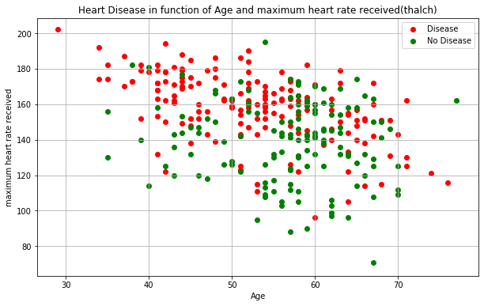

```python
# scatter plot for both target attribute
plt.figure(figsize=(10, 6))
plt.grid(True)
plt.scatter(df.age[df.target==1], df.thalach[df.target==1], color ="red")
plt.scatter(df.age[df.target==0], df.thalach[df.target==0], color ="green")
plt.title("Heart Disease in function of Age and maximum heart rate received(thalch)")
plt.xlabel("Age")
plt.ylabel("maximum heart rate received")
plt.legend(["Disease", "No Disease"])
plt.show()
```

**There is no any linear relationhip between the variable Age and Maximum heart rate receive eventhough person with maximum heart rate are more likely to have heart disease. scatter plot below shows that occurance of heart disease is significantly higher for heart rate above 140 beats per minute.**

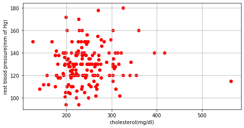

```python
# rest blood pressure vs cholesterol
plt.scatter(x = df_1["chol"], y = df_1["trestbps"], color = "red")
plt.grid(True)
plt.xlabel("cholesterol(mg/dl)")
plt.ylabel("rest blood pressure(mm of Hg)");
```

**Similarly these two variables also doesn't have any linear relationship. Also it is preety unclear to say that the person with high cholesterol have higher blood pressure.**